# 2010s Decade Project

Brian Detweiler

January 25, 2020

# Summary

Using data I have captured over the last decade, I wanted to visualize my life. I assigned a Happiness value to each day, on a scale of -10 to 10. -10 is the most unhappy, and 10 is the happiest. Zero is baseline unemotional. This is an imperfect system, but it forms a heuristic for determining what actually makes me happy.

This version is a slightly redacted version suitable for public consumption. I’m not including health information, or anything else that might be a little too personal, but the happiness scores are the same.

Some of the things that make me the happiest (which I could tell you without looking at a chart) are traveling, music, running races, and getting new tattoos.

Being fit is also a big happiness indicator, as I generally become more unhappy the heavier I get. One particular insight I gained from this project was just how effective ultra distance running has been at keeping weight off. The data really revealed this. My typical pattern is to drop a bunch of weight throughout Spring and Summer, and then I yo-yo back up to 190 or 200 lbs. But through a slew of ultramarathons, my weight has trended steadily downward and stayed there.

I also had a couple of my best races since I started ultrarunning. It has given me a level of training and fitness I never would have achieved with the shorter road runs I have always done in the past.

With all that said, each year in the last decade can be summarized with a mean Happiness score.

- **2010 Happiness Score**: 4.490411
- **2011 Happiness Score**: 2.7232877
- **2012 Happiness Score**: 4.4781421
- **2013 Happiness Score**: 3.7342466
- **2014 Happiness Score**: -1.0410959
- **2015 Happiness Score**: -1.4219178
- **2016 Happiness Score**: -1.2431694
- **2017 Happiness Score**: 1.0383562
- **2018 Happiness Score**: 3.5561644
- **2019 Happiness Score**: 2.1616438

# Travel in the 2010s

I haven’t always been able to travel much. 2010-2017 I was encumbered by 10-15 vacation days a year. I tended to hoard those and did my best to take them around long weekends. In late 2017 through early 2019, I was a contractor without PTO, so I did my best to make up the hours while traveling as much as possible.

| Year | Days Away | Percentage Away |
| --- | --- | --- |
| 2010 | 12 | 0.0328767 |
| 2011 | 21 | 0.0575342 |
| 2012 | 23 | 0.0628415 |
| 2013 | 19 | 0.0520548 |
| 2014 | 19 | 0.0520548 |
| 2015 | 17 | 0.0465753 |
| 2016 | 8 | 0.0218579 |
| 2017 | 16 | 0.0438356 |
| 2018 | **39** | **0.1068493** |
| 2019 | **55** | **0.1506849** |
| Total | 229 | 0.0627054 |

Obviously Friday-Sunday are the prime travel days. They don’t cost PTO. Monday is pretty high up there though. I’d speculate that this is because I often will take Friday-Monday off, because the last day of a festival is usually Sunday, and I need Monday for travel. Also, observed holidays may fall on a Monday if the actual holiday is on a Sunday. It is clear that Tuesday-Thursday are not economical days for traveling unless I’m taking the entire week off.

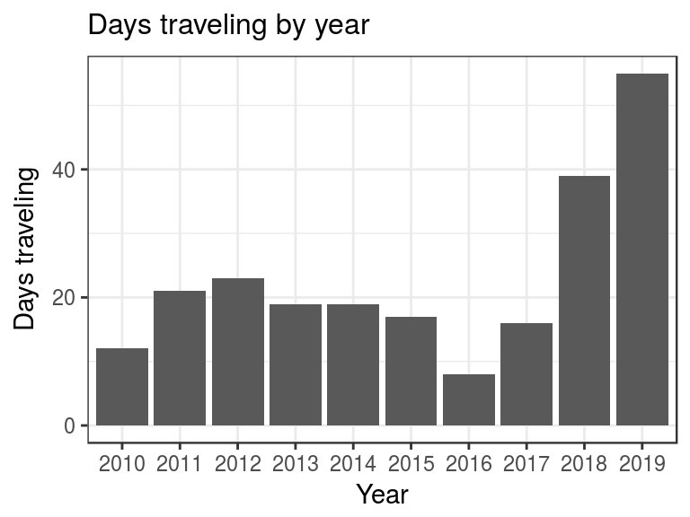

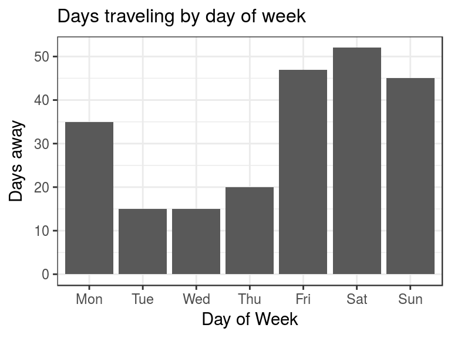

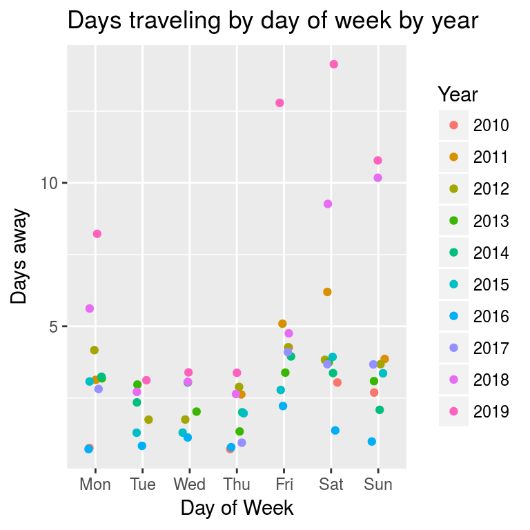

Clearly Baltimore is my most frequented city because of Maryland Deathfest, which I’ve been going to since 2014. Chicago comes in second because I love the city and because I’ve been to Riot Fest twice. Miami and Las Vegas are rising quickly though, and will likely overtake Chicago in a year or two.

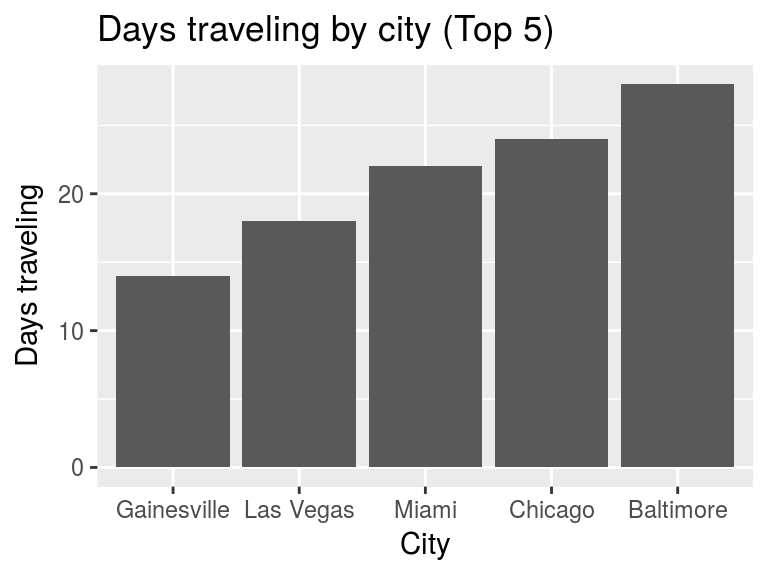

# Music

I am almost always happy when seeing a show. A band I love, comedian, musical, whatever. Entertainment doesn’t come around Omaha often, but when it does, I’m there. A couple things stick out here. 2012 was my second highest concert attendance. This is because I did both The Fest and Barge to Hell, and there were a ton of local shows that year. 2018-2019 were high because I traveled a ton for festivals and also went to every one that came through Omaha.

| Year | Concerts | Percentage |
| --- | --- | --- |
| 2010 | 65 | 0.1780822 |
| 2011 | 68 | 0.1863014 |
| 2012 | **93** | **0.2540984** |
| 2013 | 16 | 0.0438356 |
| 2014 | 56 | 0.1534247 |
| 2015 | 60 | 0.1643836 |
| 2016 | 27 | 0.0737705 |
| 2017 | 70 | 0.1917808 |
| 2018 | **80** | **0.2191781** |
| 2019 | **96** | **0.2630137** |
| Total | 631 | 0.172782 |

Menzingers are at the top of the list because they toured through Omaha 7 times in the last decade (that I was able to attend), and the other 5 were at festivals. Plus they’re just a good band. I’d still see them if they stopped through today. It’s hard to predict what my future holds for music. I know this year I will see Mayhem at least twice, and At the Gates and Napalm Death once. It’ll be interesting to see how my tastes evolve and what the touring/festival situation looks like in the 2020s.

### Most watched bands

| Show | n |
| --- | --- |
| Menzingers | 12 |
| Napalm Death | 7 |
| Every Time I Die | 6 |
| Against Me! | 5 |
| At the Gates | 5 |
| Behemoth | 5 |
| Cannibal Corpse | 5 |
| Mayhem | 5 |

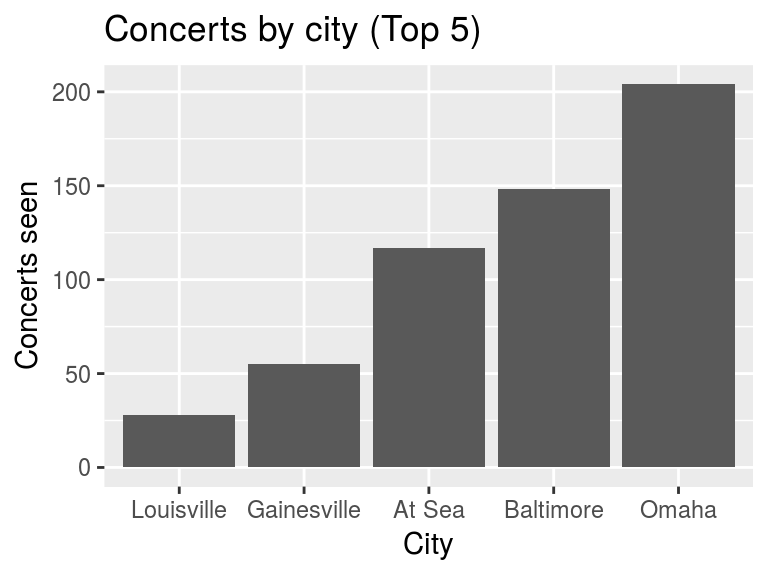

I think if I continue to go to MDF, Baltimore will surpass Omaha as the place I’ve seen the most bands within the next few years. I have already decided on ending my time with 70000 Tons, so the cruise is most likely out from here on, unless they bring Barge back. I had tossed the idea around of returning to the Fest, but I think that has definitely run its course for me.

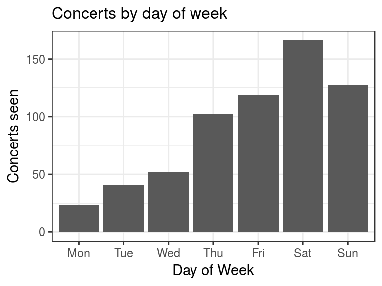

There are a couple reasons for Monday-Wednesday being so low. First, I see most of my concerts at festivals, which start no earlier than Thursday. Second, if there are local shows, I am less likely to go to them early in the week because I don’t like to mess with my sleep schedule. So this chart makes perfect sense to me.

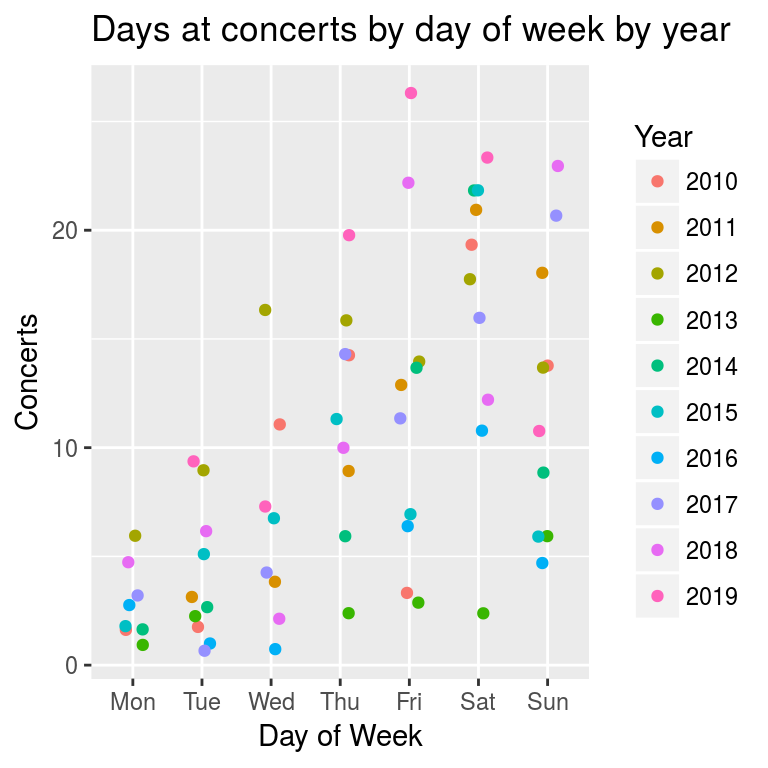

# Tattoos

Predicting more tattoos for 2020 and beyond! I took a break from tattoos in 2018 and 2019. This was because I had become obsessed with running, and nothing else seemed important. Also, with full sleeves, I was pretty happy with my current work and also out of ideas. But that is changing this year as I start on my legs.

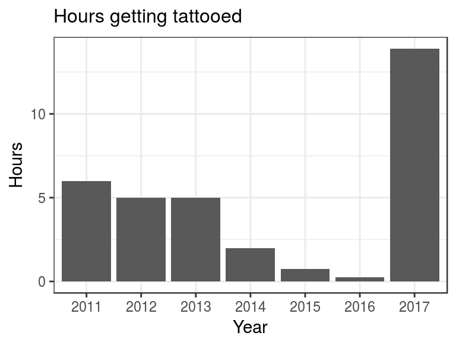

# Races

Obviously races exploded in 2018 and 2019 with my discovery of ultrarunning. I love the challenge and even though it often hurts, finishing is such a great reward in itself that by the next day, I’ve already forgotten about the pain and am signing up for another. There’s also a travel aspect to many of these races, which adds to the fun. In 2020 and beyond, I want to expand my distances and nab a few more PRs.

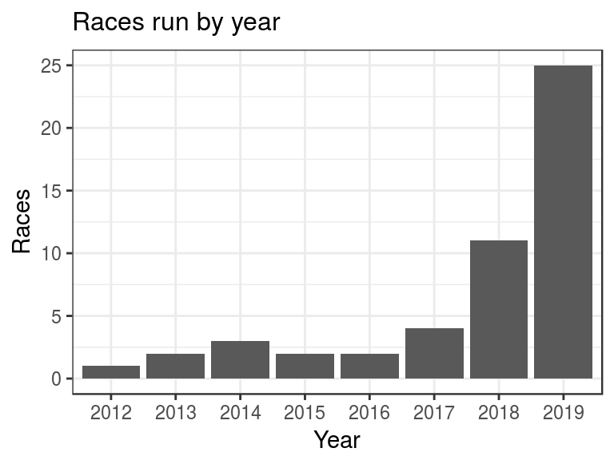

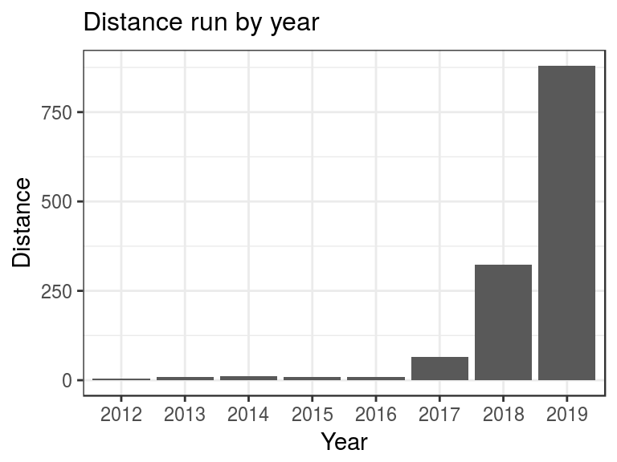

## Fastest races

I had a couple really good races in 2019. I managed to tie my PR at the 5K with the Rust Buster. I also established some stout PRs, at the mile (5:42) and the half-marathon (1:29:05). Those will be tough to beat, but I’d like to beat them all, and add a PR at the Marathon distance as well. Additionally, I’m planning on doing at least one 100 miler in 2020.

[output not shown]

# Weight

It is evident that this chart is directly correlated with my races. The high number of long distance ultras in 2018 and 2019 have dropped the weight and kept it off. The readings were mostly sparse before 2018 because I would only weigh in once in a while. In 2018 I bought a Withings WiFi scale so I am able to capture readings much more frequently with ease.

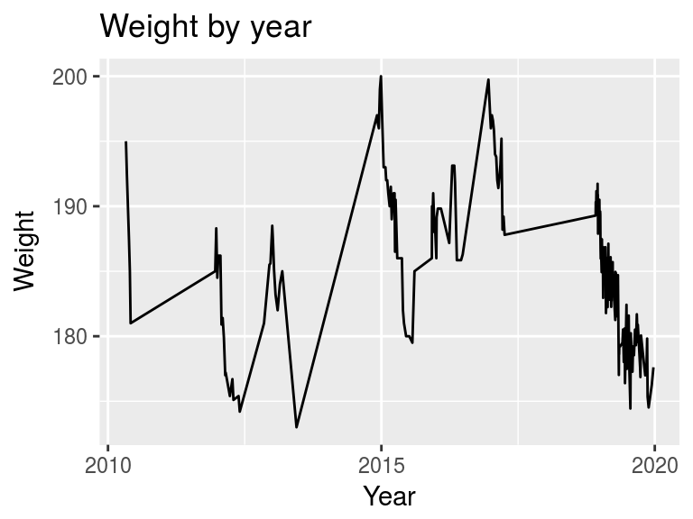

# Happiness

I did my best to assign a happiness score to each day of the year for the past decade. 0 is baseline, neither happy nor unhappy (think: driving to work on a Wednesday and traffic is mild). 10 is extremely happy, and -10 is extremely unhappy.

Obviously, the heavier I am, the more unhappy I am. This is proven here.

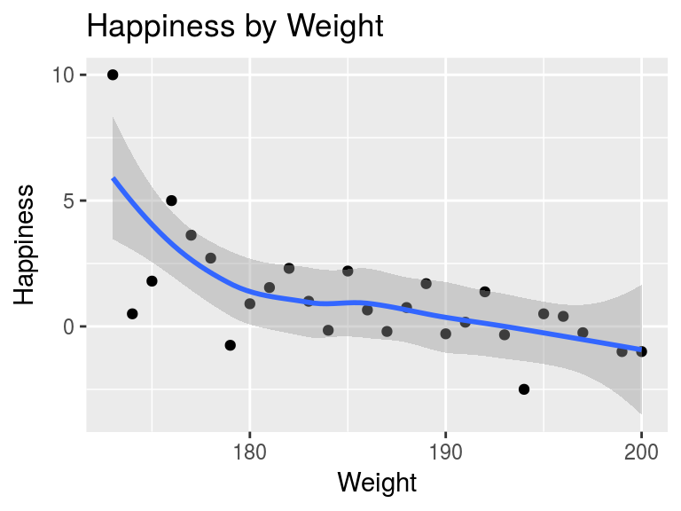

# Future Enhancements

As I look to the 2020s, how could I improve this system for the 2030s?

The most obvious thing is data collection. I hadn’t started really documenting anything until 2014. So there was a lot of filling in the blanks that needed to be done. Remembering to journal things regularly can help with future decision making.

Next, a more holistic view is needed. If you look at my categories here, they are mostly based on leisure. Looking at education and my career, as well as interpersonal relationships would have a huge impact on my scores. I don’t often think to document how my day went at work, or how much I am loving or hating school (though that is pretty much over for the foreseeable future). What I need is one of those survey button machines that you see in airport restrooms. They show a happiness scale using smiley and frowny faces. Just punch that thing before bed every night and boom, there’s my score. This might be my next project.

Finally, as this is mostly a BI project, it would be cool to turn this into a prescriptive analytics endeavor. How is this information actionable? Capturing data with the intent of using it to improve things would be more useful.